# BTS 510 Lab 6

```r
set.seed(12345)
library(tidyverse)
library(Stat2Data)
theme_set(theme_classic(base_size = 16))
```

## 0.1 Learning objectives

- Describe the logic of **linear regression**
- Describe the **assumptions** of linear regression
- Briefly **present results** of linear regression
- Use a **regression equation** to summarize a model
- Compare and contrast **observed**, **predicted**, and **residual** values

## 0.2 Data

- `ICU` data from the **Stat2Data** package
  - `ID`: Patient ID code
  - `Survive`: 1 = patient survived to discharge or 0 = patient died
  - `Age`: Age (in years)
  - `AgeGroup`: 1 = young (under 50), 2 = middle (50-69), 3 = old (70+)
  - `Sex`: 1 = female or 0 = male
  - `Infection`: 1 = infection suspected or 0 = no infection
  - `SysBP`: Systolic blood pressure (in mm of Hg)
  - `Pulse`: Heart rate (beats per minute)
  - `Emergency`: 1 = emergency admission or 0 = elective admission

## 0.3 Tasks

1. **Does blood pressure differ between those with a suspected infection and those without?** *Fit a linear regression to answer this question.*

```r
library(Stat2Data)
data(ICU)
m1 <- lm(data = ICU, SysBP ~ Infection)
summary(m1)
```

```
Call:
lm(formula = SysBP ~ Infection, data = ICU)

Residuals:
    Min      1Q  Median      3Q     Max
-87.452 -18.672  -2.062  18.548 117.328

Coefficients:
            Estimate Std. Error t value Pr(>|t|)
(Intercept)  138.672      2.986  46.440  < 2e-16 ***
Infection    -15.220      4.608  -3.303  0.00113 **
---
Signif. codes:  0 '***' 0.001 '**' 0.01 '*' 0.05 '.' 0.1 ' ' 1

Residual standard error: 32.16 on 198 degrees of freedom
Multiple R-squared:  0.05223,   Adjusted R-squared:  0.04744
F-statistic: 10.91 on 1 and 198 DF,  p-value: 0.001134
```

2. Write up the **interpretation** of the model, including:
- Intercept value, test statistic, $p$-value
- Intercept interpretation (in words)
- Slope value, test statistic, $p$-value
- Slope interpretation (in words)
- $R^2$ value, test statistic, $p$-value
- $R^2$ interpretation (in words)
3. What is the **predicted blood pressure** for someone *with a suspected infection*? What is the **predicted blood pressure** for someone *without a suspected infection*?
- Predict function

```r
newdat <- data.frame(Infection = c(0,1))
predict(m1, newdat)
```

```
       1        2
138.6724 123.4524
```

- Use R as a smart calculator

```r
bp_0 <- summary(m1)$coefficients[1] + summary(m1)$coefficients[2] * 0
bp_0
```

```
[1] 138.6724
```

```r
bp_1 <- summary(m1)$coefficients[1] + summary(m1)$coefficients[2] * 1
bp_1
```

```
[1] 123.4524
```

- Use R as a dumb calculator

```r
bp_0d <- 138.672 - 15.220 * 0
bp_0d
```

```
[1] 138.672
```

```r
bp_1d <- 138.672 - 15.220 * 1
bp_1d
```

```
[1] 123.452
```

4. Calculate the **predicted** and **residual** values for each person and add them to the original dataset. **Does it looks like the assumptions are satisfied?** Make plots to help you decide:
- Residual vs predictor
- Q-Q plot of residuals
- Histogram of residuals (all together and separately for the two groups)

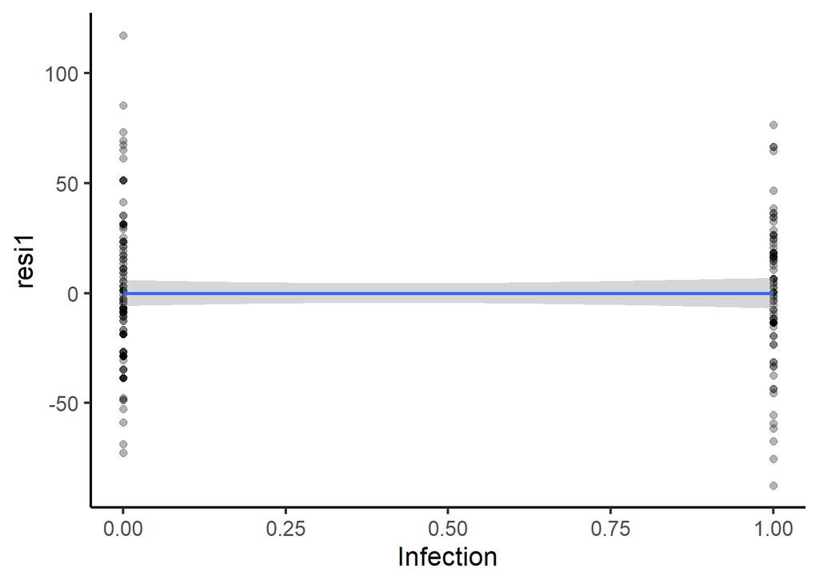

```r
ICU$pred1 <- fitted(m1)
ICU$resi1 <- residuals(m1)

ggplot(data = ICU,
       aes(x = Infection, y = resi1)) +
  geom_point(alpha = 0.3,
             size = 2) +
  geom_smooth(method = "lm")
```

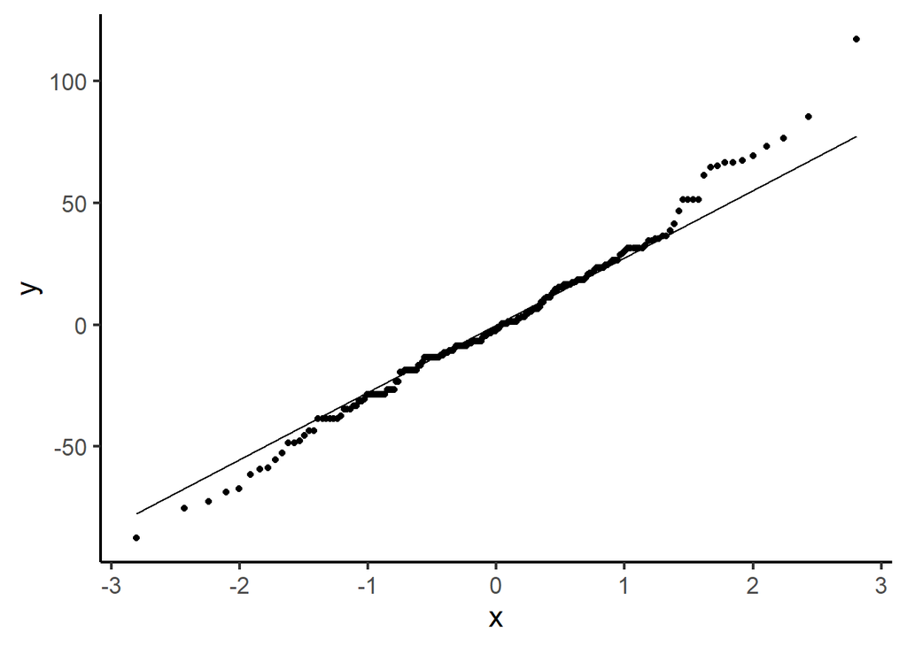

```r
ggplot(data = ICU,
       aes(sample = resi1)) +
       stat_qq() +
       stat_qq_line()
```

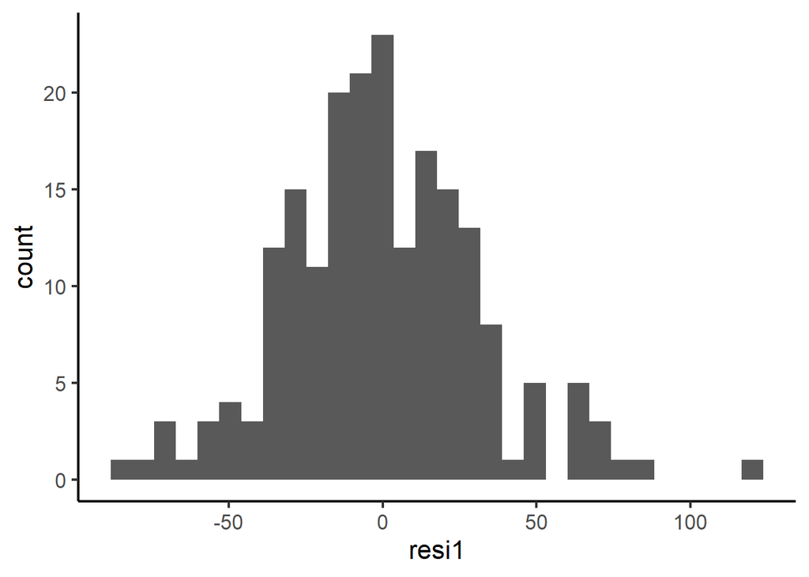

```r
ggplot(data = ICU,
       aes(x = resi1)) +
  geom_histogram()
```

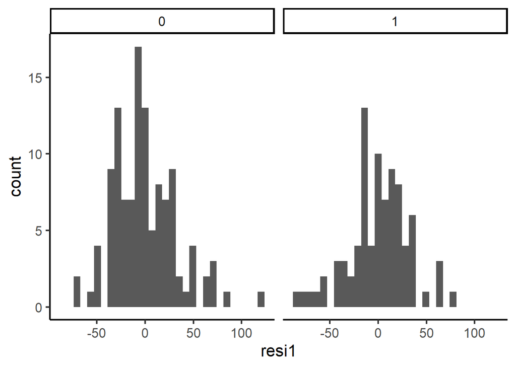

```r
ggplot(data = ICU,
       aes(x = resi1)) +
  geom_histogram() +
  facet_grid(cols = vars(Infection))
```

5. **Does blood pressure differ between those with a suspected infection and those without? How?** (Brief, simple words, no jargon, no statistics.)

# 1 Plot.

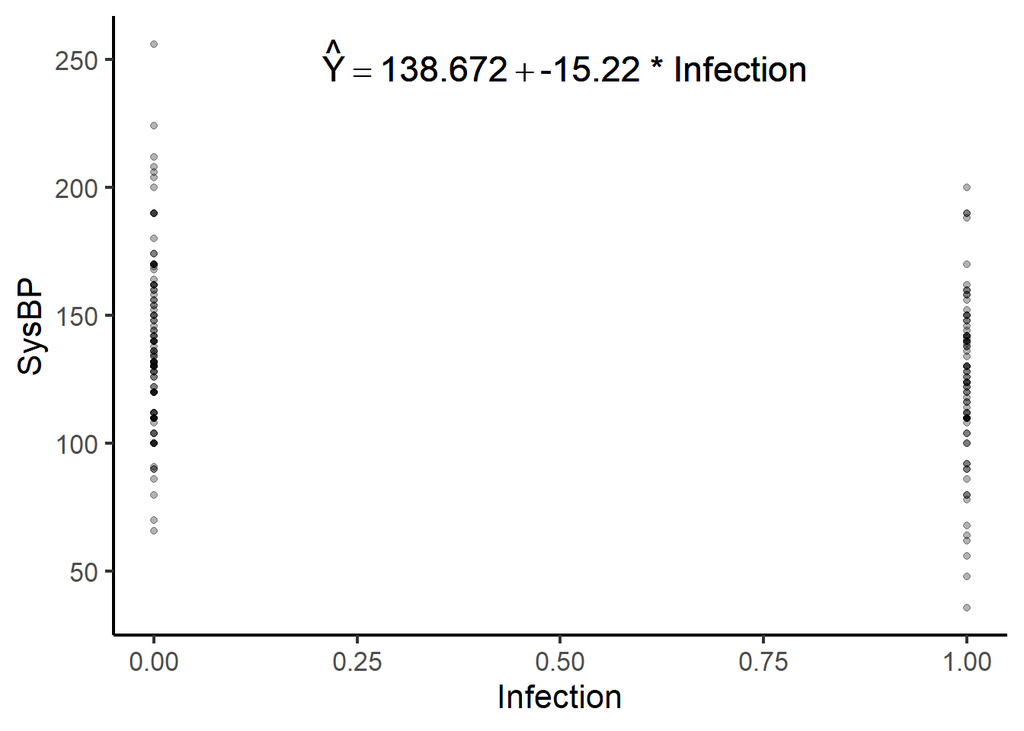

```r
int <- summary(m1)$coefficients[1]
slo <- summary(m1)$coefficients[2]
ggplot(data = ICU,
       aes(x = Infection, y = SysBP)) +
  geom_point(alpha = 0.3) +
  annotate("text",
    x = 0.5,
    y = 250,
    label = bquote(~ hat(Y) == .(round(int, 3)) + .(round(slo, 3))~"* Infection"),
    size = 6)
```